# finalproject

# Final Project: Gotta Catch ’Em All, Pokemon!

## Introduction

Pokemon has been popular since the franchise was created back in 1995. One of the first Pokemon games, Pokemon Red and Green, launched for the Nintendo Game Boy in 1996. It was a game where anyone could journey the world to catch, train, battle, and trade Pokemon. Players would go around battling each others Pokemon, striving to be the strongest in the land. Over the years, the game has slowly evolved. Many different Pokemon are added every Generation, with different appearrances and moves. The Pokemon games make everything more strategical, with the stats of every Pokemon which includes their HP, attack, defense, speed, and etc. The Pokemon can be trained to increase certain stats. Different types of Pokemon are also stronger against certain types, and weaker against others. All of these factors, including others I have not mentioned, contribute to the strategy of the game and how players determine which game they like best! We will be doing analysis so that players can decide which game they want to play, and compare Pokemon Generations. In this tutorial, we will analyze Pokemon stats in terms of type and the types of Pokemon in different Generations over time. Let’s begin!

[figure not shown]

## Data Collection

First, we must find the Pokemon dataset we would like to work with. I found a good one at https://www.kaggle.com/abcsds/pokemon. The dataset consists of 721 different stats and Pokemon including their stats and types. The data has their number, name, first and second type, and basic stats: HP, Attack, Defense, Special Attack, Special Defense, and Speed.

There are two ways to obtain the data: 1) downloading the data directly online or 2) reading in the downloaded file from our inputs folder. First, let’s import and install any packages or libraries we may need.

```r
library(tidyverse)
```

```r
library(dplyr)
library(ggplot2)
library(tidyr)
library(reshape2)
```

I decided to obtain the data by downloading the file directly off of the website. Since it is a csv file, we will use read_csv to store the data in a dataframe. We type the name of the dataframe to display it. It looks like this dataset is already tidy, so we will not have to tidy it ourselves. We can move onto Data Processing.

```r
pokemon <- read_csv("~/UMD/Senior/Spring2018/CMSC320/FinalProject/Pokemon.csv")
head(pokemon)
```

```
## # A tibble: 6 x 13
##     `#` Name        `Type 1` `Type 2` Total    HP Attack Defense `Sp. Atk`
##   <int> <chr>       <chr>    <chr>    <int> <int>  <int>   <int>     <int>
## 1     1 Bulbasaur   Grass    Poison     318    45     49      49        65
## 2     2 Ivysaur     Grass    Poison     405    60     62      63        80
## 3     3 Venusaur    Grass    Poison     525    80     82      83       100
## 4     3 VenusaurMe~ Grass    Poison     625    80    100     123       122
## 5     4 Charmander  Fire     <NA>       309    39     52      43        60
## 6     5 Charmeleon  Fire     <NA>       405    58     64      58        80
## # ... with 4 more variables: `Sp. Def` <int>, Speed <int>,
## #   Generation <int>, Legendary <chr>
```

Now we have our data. If we wanted to filter our data, we can use filter to filter our dataframe. We can filter out your favorite Pokemon by their name.

```r
number_pokemon <- pokemon %>%
  filter(Name == 'Altaria')
number_pokemon
```

```
## # A tibble: 1 x 13
##     `#` Name    `Type 1` `Type 2` Total    HP Attack Defense `Sp. Atk`
##   <int> <chr>   <chr>    <chr>    <int> <int>  <int>   <int>     <int>
## 1   334 Altaria Dragon   Flying     490    75     70      90        70
## # ... with 4 more variables: `Sp. Def` <int>, Speed <int>,
## #   Generation <int>, Legendary <chr>
```

We can also filter out by their number.

```r
number_pokemon <- pokemon %>%
  filter(pokemon$'#' == 333)
number_pokemon
```

```
## # A tibble: 1 x 13
##     `#` Name   `Type 1` `Type 2` Total    HP Attack Defense `Sp. Atk`
##   <int> <chr>  <chr>    <chr>    <int> <int>  <int>   <int>     <int>
## 1   333 Swablu Normal   Flying     310    45     40      60        40
## # ... with 4 more variables: `Sp. Def` <int>, Speed <int>,
## #   Generation <int>, Legendary <chr>
```

If we would like to filter out all Pokemon of a certain type, we can also use this filter command to help us.

```r
type_pokemon <- pokemon %>%
  filter(pokemon$'Type 1' == 'Fire')
type_pokemon
```

```
## # A tibble: 52 x 13
##      `#` Name       `Type 1` `Type 2` Total    HP Attack Defense `Sp. Atk`
##    <int> <chr>      <chr>    <chr>    <int> <int>  <int>   <int>     <int>
##  1     4 Charmander Fire     <NA>       309    39     52      43        60
##  2     5 Charmeleon Fire     <NA>       405    58     64      58        80
##  3     6 Charizard  Fire     Flying     534    78     84      78       109
##  4     6 Charizard~ Fire     Dragon     634    78    130     111       130
##  5     6 Charizard~ Fire     Flying     634    78    104      78       159
##  6    37 Vulpix     Fire     <NA>       299    38     41      40        50
##  7    38 Ninetales  Fire     <NA>       505    73     76      75        81
##  8    58 Growlithe  Fire     <NA>       350    55     70      45        70
##  9    59 Arcanine   Fire     <NA>       555    90    110      80       100
## 10    77 Ponyta     Fire     <NA>       410    50     85      55        65
## # ... with 42 more rows, and 4 more variables: `Sp. Def` <int>,
## #   Speed <int>, Generation <int>, Legendary <chr>
```

To make things a little bit more challenging, we can also filter by more specific or detailed things such as the mean of a stat depending on the type of Pokemon or in descending order by Speed. In this example, I will be looking at Dragon type Pokemon, and ordering them by Attack from highest to lowest.

```r
dragon_attack <- pokemon %>%
  filter(pokemon$'Type 1' == 'Dragon' | pokemon$'Type 2' == 'Dragon') %>%
  arrange(desc(Attack))
dragon_attack
```

```
## # A tibble: 50 x 13
##      `#` Name       `Type 1` `Type 2` Total    HP Attack Defense `Sp. Atk`
##    <int> <chr>      <chr>    <chr>    <int> <int>  <int>   <int>     <int>
##  1   384 RayquazaM~ Dragon   Flying     780   105    180     100       180
##  2   445 GarchompM~ Dragon   Ground     700   108    170     115       120
##  3   646 KyuremBla~ Dragon   Ice        700   125    170     100       120
##  4   384 Rayquaza   Dragon   Flying     680   105    150      90       150
##  5   644 Zekrom     Dragon   Electric   680   100    150     120       120
##  6   612 Haxorus    Dragon   <NA>       540    76    147      90        60
##  7   373 Salamence~ Dragon   Flying     700    95    145     130       120
##  8   373 Salamence  Dragon   Flying     600    95    135      80       110
##  9   149 Dragonite  Dragon   Flying     600    91    134      95       100
## 10     6 Charizard~ Fire     Dragon     634    78    130     111       130
## # ... with 40 more rows, and 4 more variables: `Sp. Def` <int>,
## #   Speed <int>, Generation <int>, Legendary <chr>
```

Now that we know the basics of collecting data, we can move on to plotting our data so we can further analyze it.

## Exploratory Data Analysis

We have finished scrapping, tidying, and collecting the data. We will now see if we can plot our data and see if we can observe any trends.

Many Pokemon players rave over what kind of Pokemon the next generation will have. Every generation provides players with a different set of Pokemon they can use to build a strong team. I would like to look at trends over different generations, to see if we can find any notable trends. Let’s first start of with finding the mean HP of every generation, and comparing those.

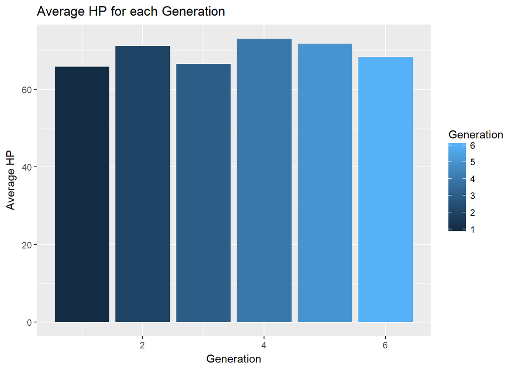

```r
average_HP <- pokemon %>%
  select(HP, Generation) %>%
  group_by(Generation) %>%
  summarize(mean_HP = mean(HP)) %>%
  ggplot(aes(x=Generation, y=mean_HP, fill=Generation)) + geom_bar(stat="identity")+
  labs(title="Average HP for each Generation",
         x = "Generation",
         y = "Average HP")
average_HP
```

Based on this chart, it looks like the Pokemon in Generation 4 had the highest average HP, while Generation 1 had the lowest. We can also do this for other stats such as Attack, Defense, and all the others! We can produce the same kind of plot with mean Defense instead of HP.

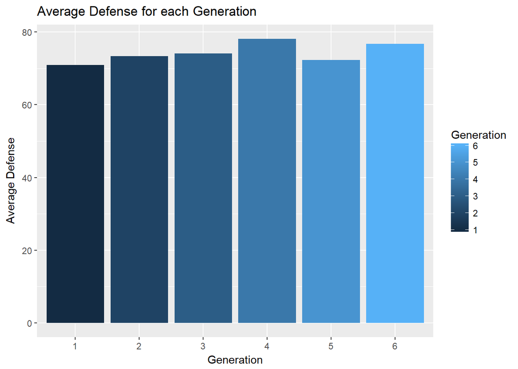

```r
average_def <- pokemon %>%
  select(Defense, Generation) %>%
  group_by(Generation) %>%
  summarize(mean_def = mean(Defense)) %>%
  ggplot(aes(x=factor(Generation), y=mean_def, fill=Generation)) + geom_bar(stat="identity")+
  labs(title="Average Defense for each Generation",
         x = "Generation",
         y = "Average Defense")
average_def
```

From this graph, we can see that Generation 1 still has the lowest average defense, and Generation 4 has the highest. However, Generation 5 looks like it has a comparitavely lower average defense than it did average HP.

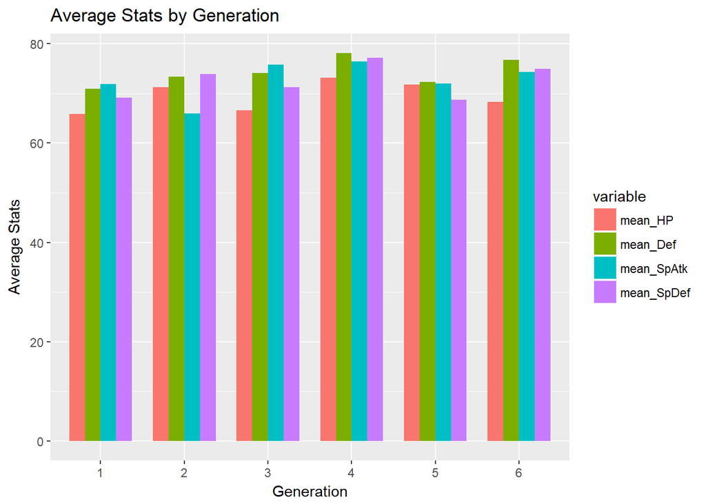

```r
avg_gen_stats <- pokemon %>%
  group_by(Generation) %>%
  summarize(mean_Total = mean(Total),mean_HP = mean(HP),mean_Atk = mean(Attack), mean_Def = mean(Defense), mean_SpAtk=mean(`Sp. Atk`), mean_SpDef = mean(`Sp. Def`), mean_Speed = mean(Speed) )

ags_mod<-melt(avg_gen_stats[,c('Generation','mean_HP', 'mean_Def', 'mean_SpAtk', 'mean_SpDef')],id.vars=1) %>%
  ggplot(aes(x=factor(Generation), y=value, width=.75)) +
  geom_bar(aes(fill=variable), stat='identity', position='dodge')+
  labs(title="Average Stats by Generation",
         x = "Generation",
         y = "Average Stats")
ags_mod
```

There are other ways to do this in R, but this is one of them.

We will now move onto Hypothesis Testing.